# Tarea_6

## Ejercicio 1

```python
from  fiona import listlayers

australiaMapsLink='https://raw.githubusercontent.com/LosEspaciales/Tarea-5/main/australiaMaps_3112.gpkg'

#layers in maps
listlayers(australiaMapsLink)
```

```
['country', 'cities', 'rivers', 'centroid', 'airports']
```

Let's read in the data:

```python
import geopandas as gpd

country=gpd.read_file(australiaMapsLink,layer='country')
cities=gpd.read_file(australiaMapsLink,layer='cities')
rivers=gpd.read_file(australiaMapsLink,layer='rivers')
centroid=gpd.read_file(australiaMapsLink,layer='centroid')
airports=gpd.read_file(australiaMapsLink,layer='airports')
```

```python
import pandas as pd

portsFileLink="https://github.com/CienciaDeDatosEspacial/GeoDataFrame_Analytics/raw/main/data/UpdatedPub150.csv"
infoseaports=pd.read_csv(portsFileLink)

#columns available (so many)
infoseaports.columns.to_list()
```

```
['World Port Index Number',
 'Region Name',
 'Main Port Name',
 'Alternate Port Name',
 'UN/LOCODE',
 'Country Code',
 'World Water Body',
 'IHO S-130 Sea Area',
 'Sailing Direction or Publication',
 'Publication Link',
 'Standard Nautical Chart',
 'IHO S-57 Electronic Navigational Chart',
 'IHO S-101 Electronic Navigational Chart',
 'Digital Nautical Chart',
 'Tidal Range (m)',
 'Entrance Width (m)',
 'Channel Depth (m)',
 'Anchorage Depth (m)',
 'Cargo Pier Depth (m)',
 'Oil Terminal Depth (m)',
 'Liquified Natural Gas Terminal Depth (m)',
 'Maximum Vessel Length (m)',
 'Maximum Vessel Beam (m)',
 'Maximum Vessel Draft (m)',
 'Offshore Maximum Vessel Length (m)',
 'Offshore Maximum Vessel Beam (m)',
 'Offshore Maximum Vessel Draft (m)',
 'Harbor Size',
 'Harbor Type',
 'Harbor Use',
 'Shelter Afforded',
 'Entrance Restriction - Tide',
 'Entrance Restriction - Heavy Swell',
 'Entrance Restriction - Ice',
 'Entrance Restriction - Other',
 'Overhead Limits',
 'Underkeel Clearance Management System',
 'Good Holding Ground',
 'Turning Area',
 'Port Security',
```

[output cut: 53 more lines]

```
 'Services - Electrical Repair',
 'Services - Ice Breaking',
 'Services - Diving',
 'Supplies - Provisions',
 'Supplies - Potable Water',
 'Supplies - Fuel Oil',
 'Supplies - Diesel Oil',
 'Supplies - Aviation Fuel',
 'Supplies - Deck',
 'Supplies - Engine',
 'Repairs',
 'Dry Dock',
 'Railway',
 'Latitude',
 'Longitude']
```

Let's do some preprocessing:

```python
#rename
infoseaports.rename(columns={'Main Port Name':'portName'},inplace=True)
#keep few columns
infoseaports=infoseaports.loc[:,['portName', 'Country Code','Latitude', 'Longitude']]

# we have now
infoseaports.info()
```

```
<class 'pandas.core.frame.DataFrame'>
RangeIndex: 3739 entries, 0 to 3738
Data columns (total 4 columns):
 #   Column        Non-Null Count  Dtype
---  ------        --------------  -----
 0   portName      3739 non-null   object
 1   Country Code  3739 non-null   object
 2   Latitude      3739 non-null   float64
 3   Longitude     3739 non-null   float64
dtypes: float64(2), object(2)
memory usage: 117.0+ KB
```

```python
# some rows
infoseaports.head()
```

|  | portName | Country Code | Latitude | Longitude |
| --- | --- | --- | --- | --- |
| 0 | Maurer | United States | 40.533333 | -74.250000 |
| 1 | Mangkasa Oil Terminal | Indonesia | -2.733333 | 121.066667 |
| 2 | Iharana | Madagascar | -13.350000 | 50.000000 |
| 3 | Andoany | Madagascar | -13.400000 | 48.300000 |
| 4 | Chake Chake | Tanzania | -5.250000 | 39.766667 |

Let's turn those points into projected spatial object (GDF of points):

```python
seaports=gpd.GeoDataFrame(data=infoseaports.copy(),
                           geometry=gpd.points_from_xy(infoseaports.Longitude,
                                                       infoseaports.Latitude),
                          crs=4326)
seaports_australia=seaports[seaports['Country Code']=='Australia'].copy()
seaports_australia.reset_index(drop=True, inplace=True)
seaports_australia_3112=seaports_australia.to_crs(3112)
```

```python
seaports_australia_3112.crs
```

```
<Projected CRS: EPSG:3112>
Name: GDA94 / Geoscience Australia Lambert
Axis Info [cartesian]:
- E[east]: Easting (metre)
- N[north]: Northing (metre)
Area of Use:
- name: Australia - Australian Capital Territory; New South Wales; Northern Territory; Queensland; South Australia; Tasmania; Western Australia; Victoria.
- bounds: (112.85, -43.7, 153.69, -9.86)
Coordinate Operation:
- name: Geoscience Australia Standard National Scale Lambert Projection
- method: Lambert Conic Conformal (2SP)
Datum: Geocentric Datum of Australia 1994
- Ellipsoid: GRS 1980
- Prime Meridian: Greenwich
```

Let me plot seaports along with the *large* airports:

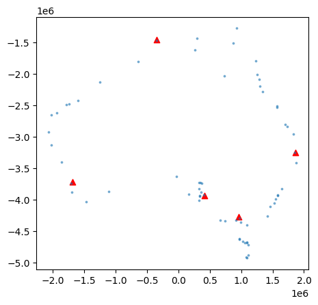

```python
# subsetting
largeAirports=airports[airports['type']=='large_airport'] #can't use "airports.type"
largeAirports.reset_index(drop=True, inplace=True)

#plotting
base=largeAirports.plot(color='red',marker="^")
seaports_australia_3112.plot(ax=base,alpha=0.5,markersize=3)
```

```python
seaports_australia_3112.head()
```

|  | portName | Country Code | Latitude | Longitude | geometry |
| --- | --- | --- | --- | --- | --- |
| 0 | Dover | Australia | -43.316667 | 147.033333 | POINT (1087783.364 -4930315.345) |
| 1 | Burnie | Australia | -41.050000 | 145.950000 | POINT (1022145.796 -4664513.364) |
| 2 | Ballina | Australia | -28.866667 | 153.566667 | POINT (1878859.725 -3411689.117) |
| 3 | Beauty Point | Australia | -41.150000 | 146.816667 | POINT (1094875.552 -4683076.964) |
| 4 | Lucinda | Australia | -18.516667 | 146.333333 | POINT (1298466.288 -2193115.291) |

```python
largeAirports.head()
```

|  | name | type | latitude_deg | longitude_deg | elevation_ft | region_name | municipality | geometry |
| --- | --- | --- | --- | --- | --- | --- | --- | --- |
| 0 | Melbourne International Airport | large_airport | -37.673302 | 144.843002 | 434.0 | Victoria | Melbourne | POINT (960390.027 -4278051.009) |
| 1 | Brisbane International Airport | large_airport | -27.384199 | 153.117004 | 13.0 | Queensland | Brisbane | POINT (1860613.688 -3244612.198) |
| 2 | Perth International Airport | large_airport | -31.940300 | 115.967003 | 67.0 | Western Australia | Perth | POINT (-1684432.427 -3723348.148) |
| 3 | Adelaide International Airport | large_airport | -34.947512 | 138.533393 | 20.0 | South Australia | Adelaide | POINT (412864.260 -3941270.535) |
| 4 | Darwin International Airport / RAAF Darwin | large_airport | -12.414970 | 130.881850 | 103.0 | Northern Territory | Darwin | POINT (-345664.176 -1452918.314) |

If both GDFs have **the same projected CRS**, we can use the *distance()* function. In this case, just two selected points:

```python
largeAirports.iloc[0].geometry.distance(seaports_australia_3112.iloc[0].geometry)/1000  # in km
```

```
664.5884634412342
```

What about computing all possible distances between those GDFs?

```python
seaports_australia_3112.geometry.apply\
(lambda g: largeAirports.geometry.distance(g)/1000)
```

|  | 0 | 1 | 2 | 3 | 4 |
| --- | --- | --- | --- | --- | --- |
| 0 | 664.588463 | 1854.416839 | 3023.565809 | 1197.382742 | 3761.258028 |
| 1 | 391.365464 | 1648.983847 | 2865.546656 | 945.676572 | 3490.737298 |
| 2 | 1262.604259 | 168.070267 | 3576.895625 | 1558.717159 | 2963.998927 |
| 3 | 426.769704 | 1629.581473 | 2940.345598 | 1007.678609 | 3536.817723 |
| 4 | 2112.167727 | 1192.331935 | 3352.506129 | 1959.677961 | 1803.068647 |
| ... | ... | ... | ... | ... | ... |
| 61 | 651.658868 | 806.959174 | 3238.347687 | 1131.244806 | 3160.218615 |
| 62 | 2775.291569 | 2002.647513 | 3383.577441 | 2479.501024 | 1216.555606 |
| 63 | 2033.336137 | 1095.248587 | 3351.598023 | 1902.306565 | 1878.575884 |
| 64 | 3240.910058 | 3677.421651 | 1243.471648 | 2598.627995 | 1729.661997 |
| 65 | 712.758323 | 734.444422 | 3268.689873 | 1165.465694 | 3130.559656 |

66 rows × 5 columns

```python
seaports_australia_3112.set_index('portName').geometry.apply\
(lambda g: largeAirports.set_index('name').geometry.distance(g)/1000)
```

| name portName | Melbourne International Airport | Brisbane International Airport | Perth International Airport | Adelaide International Airport | Darwin International Airport / RAAF Darwin |
| --- | --- | --- | --- | --- | --- |
| Dover | 664.588463 | 1854.416839 | 3023.565809 | 1197.382742 | 3761.258028 |
| Burnie | 391.365464 | 1648.983847 | 2865.546656 | 945.676572 | 3490.737298 |
| Ballina | 1262.604259 | 168.070267 | 3576.895625 | 1558.717159 | 2963.998927 |
| Beauty Point | 426.769704 | 1629.581473 | 2940.345598 | 1007.678609 | 3536.817723 |
| Lucinda | 2112.167727 | 1192.331935 | 3352.506129 | 1959.677961 | 1803.068647 |
| ... | ... | ... | ... | ... | ... |
| Port Kembla | 651.658868 | 806.959174 | 3238.347687 | 1131.244806 | 3160.218615 |
| Weipa | 2775.291569 | 2002.647513 | 3383.577441 | 2479.501024 | 1216.555606 |
| Townsville | 2033.336137 | 1095.248587 | 3351.598023 | 1902.306565 | 1878.575884 |
| Port Walcott | 3240.910058 | 3677.421651 | 1243.471648 | 2598.627995 | 1729.661997 |
| Sydney | 712.758323 | 734.444422 | 3268.689873 | 1165.465694 | 3130.559656 |

66 rows × 5 columns

```python
seaports_australia_3112.set_index('portName').geometry.apply\
(lambda g: largeAirports.set_index('name').geometry.distance(g)/1000).\
sort_index(axis=0).sort_index(axis=1)
```

| name portName | Adelaide International Airport | Brisbane International Airport | Darwin International Airport / RAAF Darwin | Melbourne International Airport | Perth International Airport |
| --- | --- | --- | --- | --- | --- |
| Albany | 1878.175154 | 3416.684096 | 2815.472432 | 2435.182019 | 384.225804 |
| Ardrossan | 80.019657 | 1631.980784 | 2529.626327 | 720.204830 | 2049.116205 |
| Ballina | 1558.717159 | 168.070267 | 2963.998927 | 1262.604259 | 3576.895625 |
| Batemans Bay | 1058.736672 | 955.463941 | 3212.250154 | 524.785710 | 3166.158422 |
| Beauty Point | 1007.678609 | 1629.581473 | 3536.817723 | 426.769704 | 2940.345598 |
| ... | ... | ... | ... | ... | ... |
| Weipa | 2479.501024 | 2002.647513 | 1216.555606 | 2775.291569 | 3383.577441 |
| Welshpool | 823.014372 | 1392.130776 | 3284.246655 | 183.551229 | 2859.408875 |
| Western Port | 709.393357 | 1413.245949 | 3195.164448 | 83.093169 | 2746.504332 |
| Whyalla | 228.614239 | 1602.636024 | 2373.292327 | 835.298205 | 2016.826775 |
| Wyndham | 2379.967832 | 2883.121141 | 458.109525 | 2943.872306 | 2184.598814 |

66 rows × 5 columns

```python
distanceMatrixKM_sea_air= seaports_australia_3112.set_index('portName').geometry.apply\
                          (lambda g: largeAirports.set_index('name').geometry.distance(g)/1000).\
                          sort_index(axis=0).sort_index(axis=1)
```

```python
distanceMatrixKM_sea_air.mean(axis=1).sort_values(ascending=True) #axis=0?
```

```
portName
Port Adelaide      1392.288164
Ardrossan          1402.189561
Port Pirie         1404.641519
Wallaroo           1407.331177
Port Bonython      1408.941915
                      ...
Useless Loop       2544.636767
Thursday Island    2554.344698
Onslow             2595.126457
Cape Cuvier        2613.166122
Point Murat        2654.053974
Length: 66, dtype: float64
```

```python
SomeStats=pd.DataFrame()
SomeStats['mean']=distanceMatrixKM_sea_air.mean(axis=1)
SomeStats['min']=distanceMatrixKM_sea_air.min(axis=1)
SomeStats['max']=distanceMatrixKM_sea_air.max(axis=1)

# see some
SomeStats.head(10)
```

| portName | mean | min | max |
| --- | --- | --- | --- |
| Albany | 2185.947901 | 384.225804 | 3416.684096 |
| Ardrossan | 1402.189561 | 80.019657 | 2529.626327 |
| Ballina | 1906.057248 | 168.070267 | 3576.895625 |
| Batemans Bay | 1783.478980 | 524.785710 | 3212.250154 |
| Beauty Point | 1908.238621 | 426.769704 | 3536.817723 |
| Botany Bay | 1806.853208 | 706.300297 | 3270.663768 |
| Brisbane | 1874.413816 | 12.176131 | 3566.844151 |
| Broome | 2323.608681 | 1123.550932 | 3300.342434 |
| Bunbury | 2265.907368 | 154.630531 | 3609.886064 |
| Bundaberg | 1963.987050 | 285.791178 | 3592.873803 |

We can also use **idxmax** to get the particular locations:

```python
distanceMatrixKM_sea_air.idxmax(axis=1)
```

```
portName
Albany                      Brisbane International Airport
Ardrossan       Darwin International Airport / RAAF Darwin
Ballina                        Perth International Airport
Batemans Bay    Darwin International Airport / RAAF Darwin
Beauty Point    Darwin International Airport / RAAF Darwin
                                   ...
Weipa                          Perth International Airport
Welshpool       Darwin International Airport / RAAF Darwin
Western Port    Darwin International Airport / RAAF Darwin
Whyalla         Darwin International Airport / RAAF Darwin
Wyndham                    Melbourne International Airport
Length: 66, dtype: object
```

```python
distanceMatrixKM_sea_air.idxmax(axis=0)
```

```
name
Adelaide International Airport                Point Murat
Brisbane International Airport                Cape Cuvier
Darwin International Airport / RAAF Darwin          Dover
Melbourne International Airport               Point Murat
Perth International Airport                     Bundaberg
dtype: object
```

```python
distanceMatrixKM_sea_air.idxmin(axis=1)
```

```
portName
Albany                         Perth International Airport
Ardrossan                   Adelaide International Airport
Ballina                     Brisbane International Airport
Batemans Bay               Melbourne International Airport
Beauty Point               Melbourne International Airport
                                   ...
Weipa           Darwin International Airport / RAAF Darwin
Welshpool                  Melbourne International Airport
Western Port               Melbourne International Airport
Whyalla                     Adelaide International Airport
Wyndham         Darwin International Airport / RAAF Darwin
Length: 66, dtype: object
```

```python
distanceMatrixKM_sea_air.idxmin(axis=0)
```

```
name
Adelaide International Airport                Port Adelaide
Brisbane International Airport                     Brisbane
Darwin International Airport / RAAF Darwin           Darwin
Melbourne International Airport                   Melbourne
Perth International Airport                       Fremantle
dtype: object
```

## Ejercicio 2

```python
rivers.head()
```

|  | NAME | SYSTEM | geometry |
| --- | --- | --- | --- |
| 0 | Murray | None | MULTILINESTRING ((746729.373 -3859608.408, 711... |
| 1 | Darling | None | LINESTRING (746729.373 -3859608.408, 755420.07... |

```python
rivers[rivers.NAME.str.contains('Murray')]
```

|  | NAME | SYSTEM | geometry |
| --- | --- | --- | --- |
| 0 | Murray | None | MULTILINESTRING ((746729.373 -3859608.408, 711... |

You can see that distance works between these two elements:

```python
rivers[rivers.NAME.str.contains('Murray')].iloc[0].geometry.distance(largeAirports.set_index('name').geometry)/1000
```

```
name
Melbourne International Airport                178.934715
Brisbane International Airport                1053.111624
Perth International Airport                   2189.213675
Adelaide International Airport                  85.642665
Darwin International Airport / RAAF Darwin    2544.741190
Name: geometry, dtype: float64
```

Based on what we did previously, let's compute all the distances:

```python
distanceMatrixKM_riv_air=rivers.set_index('NAME').geometry.apply\
(lambda g: largeAirports.set_index('name').geometry.distance(g)/1000).\
sort_index(axis=0).sort_index(axis=1)
distanceMatrixKM_riv_air
```

| name NAME | Adelaide International Airport | Brisbane International Airport | Darwin International Airport / RAAF Darwin | Melbourne International Airport | Perth International Airport |
| --- | --- | --- | --- | --- | --- |
| Darling | 343.707167 | 582.232895 | 2223.359217 | 469.835169 | 2434.977321 |
| Murray | 85.642665 | 1053.111624 | 2544.741190 | 178.934715 | 2189.213675 |

Here, we see one row (river), that tells the distance to each column (large airport):

```python
distanceMatrixKM_riv_air.loc['Murray'].sort_values()
```

```
name
Adelaide International Airport                  85.642665
Melbourne International Airport                178.934715
Brisbane International Airport                1053.111624
Perth International Airport                   2189.213675
Darwin International Airport / RAAF Darwin    2544.741190
Name: Murray, dtype: float64
```

Let's try a simple plot of the river and the airports:

```python
!pip install mapclassify
```

```python
base=largeAirports.explore(color='red',marker_kwds=dict(radius=10))
rivers[rivers.NAME.str.contains('Murray')].explore(m=base)
```

Make this Notebook Trusted to load map: File -> Trust Notebook

[interactive chart not shown]

Let's dissolve the ones that belong to a system into a multiline:

```python
systems=rivers.dissolve(by='NAME')
systems
```

| NAME | geometry | SYSTEM |
| --- | --- | --- |
| Darling | LINESTRING (746729.373 -3859608.408, 755420.07... | None |
| Murray | MULTILINESTRING ((746729.373 -3859608.408, 711... | None |

Let's do some basic formatting:

```python
systems.reset_index(drop=False,inplace=True)
systems.drop(columns='NAME',inplace=True)
systems
```

|  | geometry | SYSTEM |
| --- | --- | --- |
| 0 | LINESTRING (746729.373 -3859608.408, 755420.07... | None |
| 1 | MULTILINESTRING ((746729.373 -3859608.408, 711... | None |

Another distance matrix:

```python
distanceMatrixKM_sys_air=systems.set_index('SYSTEM').geometry.apply\
(lambda g: largeAirports.set_index('name').geometry.distance(g)/1000).\
sort_index(axis=0).sort_index(axis=1)

distanceMatrixKM_sys_air
```

| name SYSTEM | Adelaide International Airport | Brisbane International Airport | Darwin International Airport / RAAF Darwin | Melbourne International Airport | Perth International Airport |
| --- | --- | --- | --- | --- | --- |
| None | 343.707167 | 582.232895 | 2223.359217 | 469.835169 | 2434.977321 |
| None | 85.642665 | 1053.111624 | 2544.741190 | 178.934715 | 2189.213675 |

This time, let me get all the minimum distances:

```python
mins=distanceMatrixKM_sys_air.idxmin(axis="columns") #
mins
```

```
SYSTEM
None    Adelaide International Airport
None    Adelaide International Airport
dtype: object
```

```python
mins.iloc[0]
```

```
'Adelaide International Airport'
```

Let's see now:

```python
base=systems.explore()
largeAirports[largeAirports.name.isin(mins)].explore(m=base,color='red',marker_kwds=dict(radius=10))
largeAirports[~largeAirports.name.isin(mins)].explore(m=base,color='blue',marker_kwds=dict(radius=5))
```

Make this Notebook Trusted to load map: File -> Trust Notebook

[interactive chart not shown]

## Ejercicio 3

```python
systems.convex_hull
```

```
0    POLYGON ((746729.373 -3859608.408, 755420.073 ...
1    POLYGON ((1267047.547 -4222620.703, 485782.185...
dtype: geometry
```

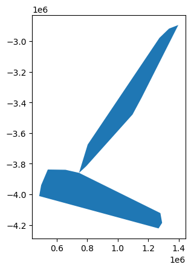

```python
# see them
systems.convex_hull.plot()
```

Now, a GDF for the hulls:

```python
systems_hulls=systems.convex_hull.to_frame()
systems_hulls['system']=['Darling', 'Murray']
systems_hulls.rename(columns={0:'geometry'},inplace=True)
systems_hulls=systems_hulls.set_geometry('geometry')
systems_hulls.crs="EPSG:3112"
systems_hulls
```

|  | geometry | system |
| --- | --- | --- |
| 0 | POLYGON ((746729.373 -3859608.408, 755420.073 ... | Darling |
| 1 | POLYGON ((1267047.547 -4222620.703, 485782.185... | Murray |

Next, the distance matrix:

```python
distanceMatrixKM_sysHull_air=systems_hulls.set_index('system').geometry.apply\
(lambda g: largeAirports.set_index('name').geometry.distance(g)/1000).\
sort_index(axis=0).sort_index(axis=1)

distanceMatrixKM_sysHull_air
```

| name system | Adelaide International Airport | Brisbane International Airport | Darwin International Airport / RAAF Darwin | Melbourne International Airport | Perth International Airport |
| --- | --- | --- | --- | --- | --- |
| Darling | 343.707167 | 572.895495 | 2223.359217 | 469.835169 | 2434.977321 |
| Murray | 84.095757 | 1053.111624 | 2544.741190 | 133.629689 | 2189.213675 |

All the minimal differences:

```python
mins=distanceMatrixKM_sysHull_air.idxmin(axis="columns")
mins
```

```
system
Darling    Adelaide International Airport
Murray     Adelaide International Airport
dtype: object
```

```python
base=systems_hulls.explore()
largeAirports[largeAirports.name.isin(mins)].explore(m=base,color='red',marker_kwds=dict(radius=10))
largeAirports[~largeAirports.name.isin(mins)].explore(m=base,color='blue',marker_kwds=dict(radius=5))
```

Make this Notebook Trusted to load map: File -> Trust Notebook

[interactive chart not shown]

## Ejercicio 4

```python
distanceMatrixKM_riv_air
```

| name NAME | Adelaide International Airport | Brisbane International Airport | Darwin International Airport / RAAF Darwin | Melbourne International Airport | Perth International Airport |
| --- | --- | --- | --- | --- | --- |
| Darling | 343.707167 | 582.232895 | 2223.359217 | 469.835169 | 2434.977321 |
| Murray | 85.642665 | 1053.111624 | 2544.741190 | 178.934715 | 2189.213675 |

```python
distanceMatrixKM_riv_air.loc['Darling'].min() # I chose min
```

```
343.7071671041337
```

We can use any value to create a buffer:

```python
minMts=distanceMatrixKM_riv_air.loc['Darling'].min()*100 # km

rivers[rivers.NAME=='Darling'].buffer(distance = minMts)
```

```
1    POLYGON ((722479.905 -3820622.217, 723634.408 ...
dtype: geometry
```

```python
bufferAroundDarling=rivers[rivers.NAME=='Darling'].buffer(distance = minMts)
bufferAsBase=bufferAroundDarling.explore(color='red')
rivers[rivers.NAME=='Darling'].explore(m=bufferAsBase,color='blue',style_kwds={'weight':0.5})
```

Make this Notebook Trusted to load map: File -> Trust Notebook

[interactive chart not shown]

Above we used the buffer (red polygon), and the river (blue). Let me add a layer of airports (small ones):

```python
small_airports=airports[airports['type']=='small_airport']

rivers[rivers.NAME=='Darling'].explore(m=bufferAsBase,color='blue',style_kwds={'weight':0.5})
small_airports.explore(m=bufferAsBase,color='black')
```

Make this Notebook Trusted to load map: File -> Trust Notebook

[interactive chart not shown]

Now, we can use the buffer (polygon) to keep the airports that are at that particular distance around the river:

```python
riversWithinBuffer=small_airports.clip(mask=bufferAroundDarling)
#
riversWithinBuffer
```

|  | name | type | latitude_deg | longitude_deg | elevation_ft | region_name | municipality | geometry |
| --- | --- | --- | --- | --- | --- | --- | --- | --- |
| 2179 | Trentham Cliffs airstrip | small_airport | -34.234051 | 142.267845 | NaN | New South Wales | Trentham Cliffs | POINT (757771.974 -3879900.604) |
| 620 | Wentworth Airport | small_airport | -34.088299 | 141.891998 | 37.0 | New South Wales | Wentworth | POINT (724380.823 -3861624.738) |
| 948 | Pooncarie Airport | small_airport | -33.373263 | 142.586439 | 50.0 | New South Wales | None | POINT (793410.715 -3787116.882) |
| 1906 | Louth Airport | small_airport | -30.531414 | 145.128413 | NaN | New South Wales | Louth | POINT (1055380.796 -3494347.368) |
| 2217 | Murtee Station | small_airport | -31.576524 | 143.496093 | NaN | New South Wales | Wilcannia | POINT (892236.569 -3596039.911) |
| 914 | Wilcannia Airport | small_airport | -31.522082 | 143.378358 | 250.0 | New South Wales | None | POINT (881640.949 -3589245.366) |
| 2169 | Tilpa Airport | small_airport | -30.925497 | 144.419403 | NaN | New South Wales | Tilpa | POINT (984719.133 -3531674.423) |
| 750 | Augathella Airport | small_airport | -25.754999 | 146.587006 | NaN | Queensland | None | POINT (1245576.001 -2986938.575) |
| 1566 | Attica State Forest Airstrip | small_airport | -25.244083 | 147.381276 | NaN | Queensland | Attica State Forest | POINT (1329830.352 -2939446.895) |
| 1572 | Upper Warrego Airstrip | small_airport | -25.194258 | 147.142757 | 1696.0 | Queensland | Babbiloora | POINT (1306783.041 -2931520.385) |
| 1661 | Mount Moffatt Airstrip | small_airport | -25.041314 | 147.937575 | 2323.0 | Queensland | Carnarvon National Park | POINT (1387350.012 -2923392.232) |
| 776 | Torres Park Homestead Airport | small_airport | -25.116699 | 147.167007 | NaN | Queensland | None | POINT (1310073.469 -2923328.099) |
| 1620 | Buckland station | small_airport | -24.694517 | 147.501497 | NaN | Queensland | Buckland QLD 4722 | POINT (1348184.364 -2880898.739) |
| 1607 | Bourke no.2 | small_airport | -30.014772 | 145.826780 | NaN | New South Wales | Bourke | POINT (1126745.821 -3443988.829) |
| 2036 | North Bourke airstrip | small_airport | -29.621949 | 146.071258 | NaN | New South Wales | North Bourke NSW 2840 | POINT (1154096.048 -3403343.499) |
| 992 | Engonnia Airport | small_airport | -29.311175 | 145.857475 | NaN | New South Wales | None | POINT (1136926.451 -3367495.382) |
| 1753 | Enngonia station | small_airport | -29.069393 | 145.998774 | NaN | New South Wales | Enngonia NSW 2839 | POINT (1152958.764 -3342414.251) |
| 1754 | Enngonia | small_airport | -29.034728 | 146.280899 | NaN | New South Wales | Enngonia NSW 2839 | POINT (1180353.203 -3341253.817) |
| 743 | Wyandra Airport | small_airport | -27.266701 | 145.990005 | 244.0 | Queensland | None | POINT (1170920.897 -3145860.673) |
| 1513 | Rosevale Resort Airport | small_airport | -27.133301 | 145.899994 | NaN | Queensland | None | POINT (1163537.399 -3130490.091) |
| 2079 | Whurlie Station Airport | small_airport | -33.023682 | 142.347431 | NaN | New South Wales | Pooncarie | POINT (773915.094 -3747198.354) |
| 1950 | Menindee Airport | small_airport | -32.944155 | 142.392727 | NaN | New South Wales | Menindee | POINT (778692.855 -3738739.425) |
| 1951 | Menindee Number 2 Airport | small_airport | -32.847423 | 142.476044 | 214.0 | New South Wales | Menindee | POINT (787129.321 -3728631.407) |
| 1957 | Tolarno Station South Airport | small_airport | -32.830738 | 142.393456 | 194.0 | New South Wales | Menindee | POINT (779593.834 -3726283.775) |
| 1952 | Bindara Airstrip | small_airport | -32.736805 | 142.355986 | NaN | New South Wales | Menindee | POINT (776805.767 -3715734.101) |
| 1955 | Menindee Number 3 Airport | small_airport | -32.624012 | 142.441130 | 200.0 | New South Wales | Menindee | POINT (785542.470 -3703876.721) |
| 1954 | Bono Station Airport | small_airport | -32.565419 | 142.402085 | NaN | New South Wales | Menindee | POINT (782345.090 -3697199.741) |
| 1956 | Menindee airfield no 4 | small_airport | -32.467468 | 142.908508 | NaN | New South Wales | Menindee | POINT (830186.348 -3689696.829) |
| 1948 | Menindee Airport | small_airport | -32.366699 | 142.404999 | NaN | New South Wales | Menindee | POINT (784077.145 -3675403.730) |
| 1581 | Barraroo Airstrip | small_airport | -32.117535 | 142.982026 | NaN | New South Wales | Barraroo | POINT (839774.337 -3651795.326) |
| 1953 | four mile lake airstrip | small_airport | -32.087571 | 142.894764 | NaN | New South Wales | Menindee | POINT (831862.457 -3647928.789) |

```python
bufferAsBase=bufferAroundDarling.explore(color='red')
rivers[rivers.NAME=='Darling'].explore(m=bufferAsBase,color='blue',style_kwds={'weight':0.5})
riversWithinBuffer.explore(m=bufferAsBase,color='black')
```

Make this Notebook Trusted to load map: File -> Trust Notebook

[interactive chart not shown]

```python
distanceMatrixKM_riv_air.min(axis=1).min()
```

```
85.6426650255539
```

```python
minMinMts_5=5*distanceMatrixKM_riv_air.min(axis=1).min()*100


allMinBuffer=rivers.buffer(distance = minMinMts_5).explore(color='red')
rivers.explore(m=allMinBuffer,color='blue',style_kwds={'weight':0.5})
```

Make this Notebook Trusted to load map: File -> Trust Notebook

[interactive chart not shown]

```python
riversAll_buf=rivers.buffer(distance = minMinMts_5)
riversAll_buf
```

```
0    POLYGON ((485972.366 -3899250.819, 486809.963 ...
1    POLYGON ((714381.014 -3818209.570, 715819.370 ...
dtype: geometry
```

Now keep small airports in buffer:

```python
allRiversWithinBuffs=small_airports.clip(riversAll_buf)
allRiversWithinBuffs
```

|  | name | type | latitude_deg | longitude_deg | elevation_ft | region_name | municipality | geometry |
| --- | --- | --- | --- | --- | --- | --- | --- | --- |
| 583 | Meningie Airport | small_airport | -35.701002 | 139.345522 | NaN | South Australia | Meningie | POINT (483236.790 -4027546.360) |
| 328 | Strathalbyn Airport | small_airport | -35.317766 | 139.000023 | NaN | South Australia | Strathalbyn | POINT (453709.630 -3983831.561) |
| 2117 | Sherlock Ultralight Airfield | small_airport | -35.320278 | 139.792522 | 58.0 | South Australia | Sherlock | POINT (525561.941 -3987197.181) |
| 607 | Swan Reach Airport | small_airport | -34.556053 | 139.592156 | 36.0 | South Australia | Swan Reach | POINT (511155.569 -3901912.551) |
| 254 | Loxton Airport | small_airport | -34.474998 | 140.662994 | 38.0 | South Australia | None | POINT (609426.714 -3897740.185) |
| ... | ... | ... | ... | ... | ... | ... | ... | ... |
| 1956 | Menindee airfield no 4 | small_airport | -32.467468 | 142.908508 | NaN | New South Wales | Menindee | POINT (830186.348 -3689696.829) |
| 1948 | Menindee Airport | small_airport | -32.366699 | 142.404999 | NaN | New South Wales | Menindee | POINT (784077.145 -3675403.730) |
| 1581 | Barraroo Airstrip | small_airport | -32.117535 | 142.982026 | NaN | New South Wales | Barraroo | POINT (839774.337 -3651795.326) |
| 1953 | four mile lake airstrip | small_airport | -32.087571 | 142.894764 | NaN | New South Wales | Menindee | POINT (831862.457 -3647928.789) |
| 2216 | Wilcannia airstrip | small_airport | -31.405750 | 143.188323 | NaN | New South Wales | Wilcannia | POINT (864741.686 -3575182.347) |

72 rows × 8 columns

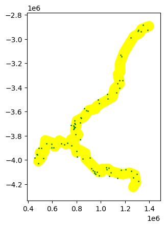

```python
base=riversAll_buf.plot(color='yellow')
allRiversWithinBuffs.plot(ax=base, color='green', markersize=1)
```

```python
# folium

base=riversAll_buf.explore(color='yellow')
allRiversWithinBuffs.explore(m=base, color='green')
```

Make this Notebook Trusted to load map: File -> Trust Notebook

[interactive chart not shown]